# Accessible Data Visualization

Making Data Clearer for Everyone

Shanice Smith

2026-11-11

## Situation: Data visualization is about communication

### We use data visualizations to:

- Identify patterns and trends
- Communicate findings to stakeholders
- Support informed business decisions

**But can everyone understand the visualizations we create?**

## Complication: A beautiful chart can still exclude people

### Not everyone experiences visual information the same way.

- **Color vision deficiencies:** Difficulty distinguishing certain colors.
- **Low vision:** Small fonts and poor contrast make charts difficult to read.
- **Color-dependent information:** Important differences may only be communicated through color.
- **Screen readers:** Charts without text descriptions can be inaccessible.

## Question: How can we make our visualizations more accessible?

### How can we improve accessibility without sacrificing quality or adding unnecessary complexity?

**The good news:** We can make meaningful improvements using tools already available in R and RStudio.

## Answer: Four practical techniques

### Small design changes can make a big difference.

#### 1. Choose accessible colors

Use color palettes designed for people with color vision deficiencies.

**R package:** `viridis`

#### 2. Don’t rely on color alone

Use direct labels, symbols, patterns, and different line types.

#### 3. Improve readability

- Larger fonts
- Strong contrast
- Clear titles and labels
- Less visual clutter

#### 4. Include alternative text

Provide written descriptions so screen reader users can understand the chart’s key message.

**R package:** `BrailleR`

## Answer: Let’s put it into practice with R

### Example: Average movie rating by genre

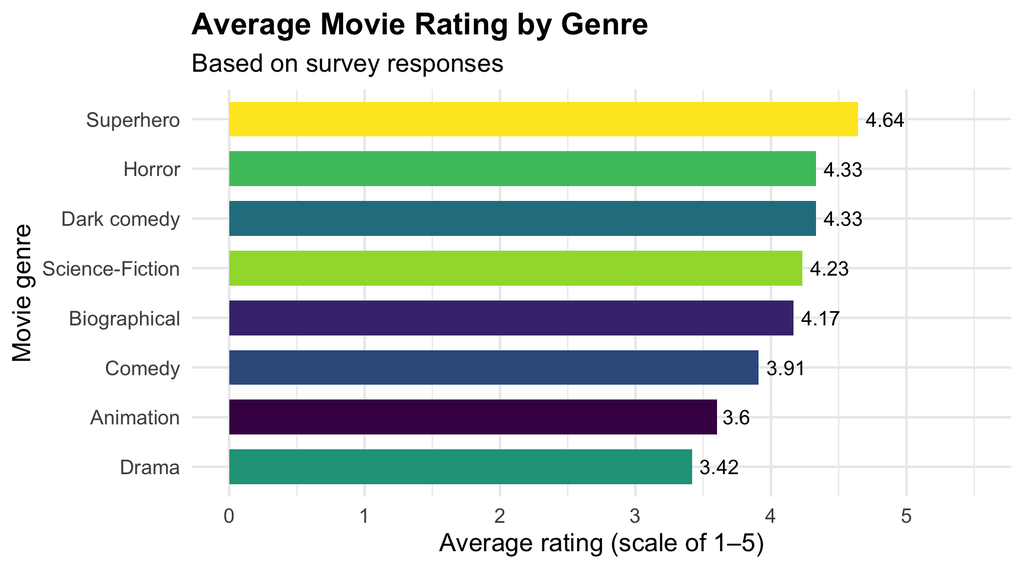

### What makes this chart more accessible?

| R code | Accessibility benefit |
| --- | --- |
| `scale_fill_viridis_d()` | Accessible color palette |
| `geom_text()` | Displays actual values |
| `base_size = 16` | Improves readability |
| `labs()` | Descriptive titles and axes |
| `fig-alt` | Provides a text description |

## Accessibility Beyond the Visual

### What does BrailleR tell us about this chart?

```
This chart has title 'Average Movie Rating by Genre'.
It has the subtitle 'Based on survey responses'.
It has x-axis 'Average rating (scale of 1–5)' with labels 0, 1, 2, 3, 4 and 5.
It has y-axis 'Movie genre' with labels Drama, Animation, Comedy, Biographical, Science-Fiction, Dark comedy, Horror and Superhero.
It has 2 layers.
Layer 1 is a bar chart with 8 (error with orientation) bars.
Bar 1 is centered at 1, and length is from 0 to 3.42 with fill colour brilliant bluish green which maps to  = Drama.
Bar 2 is centered at 2, and length is from 0 to 3.6 with fill colour very deep purple which maps to  = Animation.
Bar 3 is centered at 3, and length is from 0 to 3.91 with fill colour moderate blue which maps to  = Comedy.
Bar 4 is centered at 4, and length is from 0 to 4.17 with fill colour vivid purplish blue which maps to  = Biographical.
Bar 5 is centered at 5, and length is from 0 to 4.23 with fill colour vivid yellow green which maps to  = Science-Fiction.
Bar 6 is centered at 6, and length is from 0 to 4.33 with fill colour deep greenish blue which maps to  = Dark comedy.
Bar 7 is centered at 7, and length is from 0 to 4.33 with fill colour vivid yellowish green which maps to  = Horror.
Bar 8 is centered at 8, and length is from 0 to 4.64 with fill colour vivid greenish yellow which maps to  = Superhero.
Layer 1 has width set to 0.7.
Layer 2 is a text graph that VI cannot process.
Layer 2 has hjust set to -0.2.
Layer 2 has size set to 4.5.
```

## Why Does This Matter?

- **Alternative communication:** Provides information about a chart in text form.
- **Screen reader support:** Text descriptions can help people who cannot interpret visual charts.
- **Greater understanding:** Explains chart elements, labels, and data patterns.
- **Inclusive design:** Encourages data scientists to think beyond visual presentation.

## Conclusion: Accessibility is better data communication

### Four things to remember:

1. Design for different visual abilities.
2. Communicate information in more than one way.
3. Use R packages to simplify accessibility.
4. Test your visualizations before sharing.

### Don’t just ask whether your visualization looks good.

# Ask whether everyone can understand it.

## Further learning

- [viridis: Color palettes for R](https://sjmgarnier.github.io/viridis/)
- [ggplot2 documentation](https://ggplot2.tidyverse.org/)
- [Quarto figure documentation](https://quarto.org/docs/authoring/figures.html)
- [W3C Web Content Accessibility Guidelines (WCAG)](https://www.w3.org/WAI/WCAG22/)
- [BrailleR Package](https://github.com/ajrgodfrey/brailler)